# Visualizing buildings in Mutendere, Lusaka

Bjenk Ellefsen  
March 5, 2017

# The buildings of Mutendere

Mutendere is a suburb in the city of Lusaka, Zambia. The population of Zambia is growing rapidly and as such, many suburbs are increasing in population density in the capital.

Estimates are not easy for these smaller areas and buildings may give a sense of its population. The size of buildings is useful as a proxy to estimate population at a smaller scale when information is missing.

# Visualizing buildings

The application helps visualizing the diversity in size of the buildings in the suburb of Mutendere. This supports exploratory analysis before producing estimates.

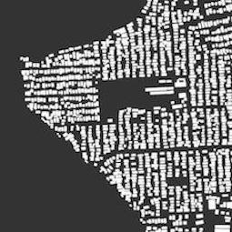

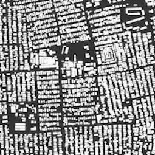

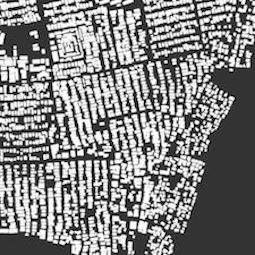

# Selecting by area

A slider allows a precise selection to view the buidings according to a range based on their area. You can observe where the largest and smallest buildings are located and get a sense of their diversity.

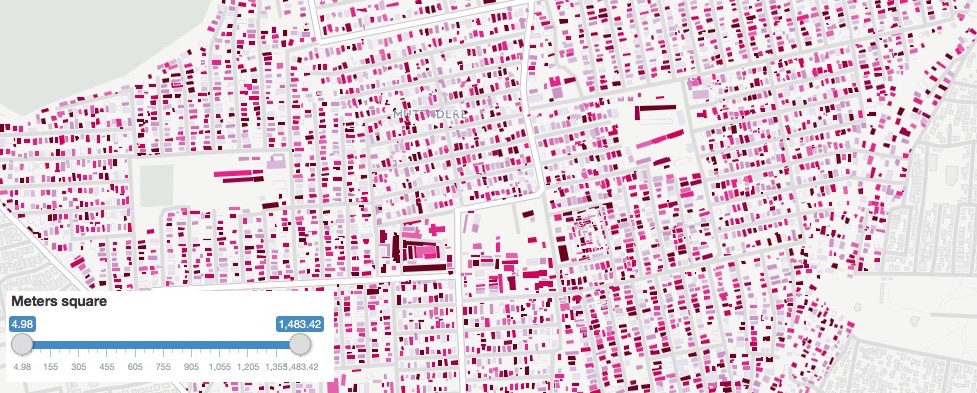

# Summarising buildings size

```r
  data2 <- data@data %>% group_by(area_m2) %>%
    mutate(group = ntile(area_m2, 5)) %>% mutate(group = factor(group)) %>%
    mutate(group = fct_recode(group, "Very small" = "1", "Small" = "2",
    "Medium" = "3", "Large" = "4", "Very large" = "5"))

data3 <- data2 %>% group_by(group) %>% tally
data3
```

[output not shown]